# Correlation and Regression Homework

## Bugs

```r
#loading in bugs
bugs <- read_csv("https://whitlockschluter.zoology.ubc.ca/wp-content/data/chapter17/chap17q25BeetleWingsAndHorns.csv")
#modeling
bugs_lm <- lm(formula = wingMass ~ hornSize, data = bugs)
bugs_lm
```

```
##
## Call:
## lm(formula = wingMass ~ hornSize, data = bugs)
##
## Coefficients:
## (Intercept)     hornSize
##      -0.129     -132.617
```

```r
summary(bugs_lm)
```

```
##
## Call:
## lm(formula = wingMass ~ hornSize, data = bugs)
##
## Residuals:
##     Min      1Q  Median      3Q     Max
## -32.857  -8.715   2.157   6.984  22.471
##
## Coefficients:
##             Estimate Std. Error t value Pr(>|t|)
## (Intercept)   -0.129      3.355  -0.038   0.9698
## hornSize    -132.617     45.146  -2.937   0.0092 **
## ---
## Signif. codes:  0 '***' 0.001 '**' 0.01 '*' 0.05 '.' 0.1 ' ' 1
##
## Residual standard error: 14.47 on 17 degrees of freedom
## Multiple R-squared:  0.3367, Adjusted R-squared:  0.2977
## F-statistic: 8.629 on 1 and 17 DF,  p-value: 0.009201
```

```r
resid(bugs_lm)
```

```
##           1           2           3           4           5           6
## -32.8573453 -11.0942627 -16.1512536 -13.6164867  -1.3985636  22.4709703
##           7           8           9          10          11          12
##   9.1878142   4.7792124   4.4921151   2.1573482  -0.1405014  -3.0362005
##          13          14          15          16          17          18
##   3.6089591  11.6089591  19.4724013  20.4724013   2.7236525  -6.3351291
##          19
## -16.3440907
```

Plotting a residual plot

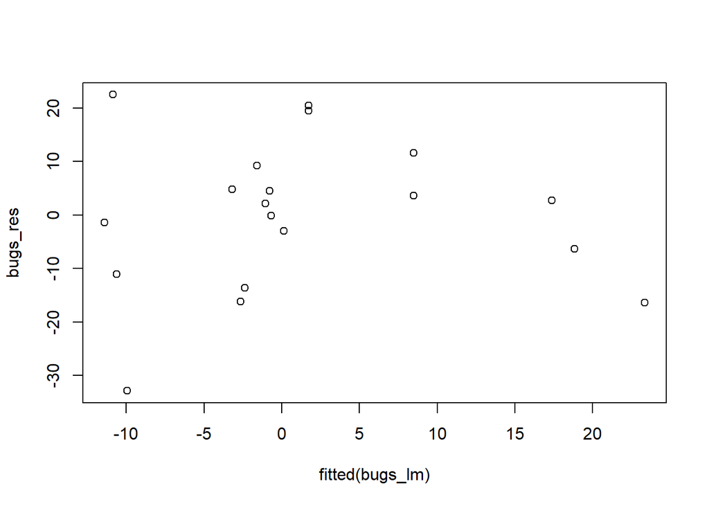

```r
bugs_res <- resid(bugs_lm)
plot(fitted(bugs_lm), bugs_res)
```

It seems to me that the points are lying above and below 0, generally telling me that there is great variance in the sample with spread out points. The residual plot shows this by not having a cloud of points above and below y=0, and there is a slight curvature tail on the right. So it would fail this assumption of homogeneity of variance.

Do other diagnostics misbehave

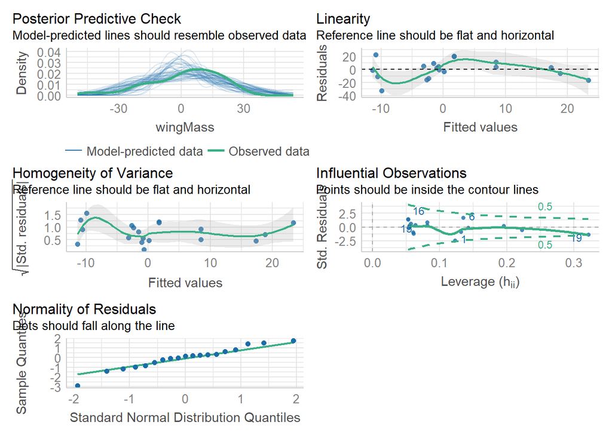

```r
check_model(bugs_lm)
```

Yes, linearity seems to not look great and the model of fit isn’t perfect but I would say the model fits okay.

## Age of teeth

```r
# loading in the data
zombies <- read_csv("https://whitlockschluter.zoology.ubc.ca/wp-content/data/chapter17/chap17q30NuclearTeeth.csv")
```

What is the slope of the regression line

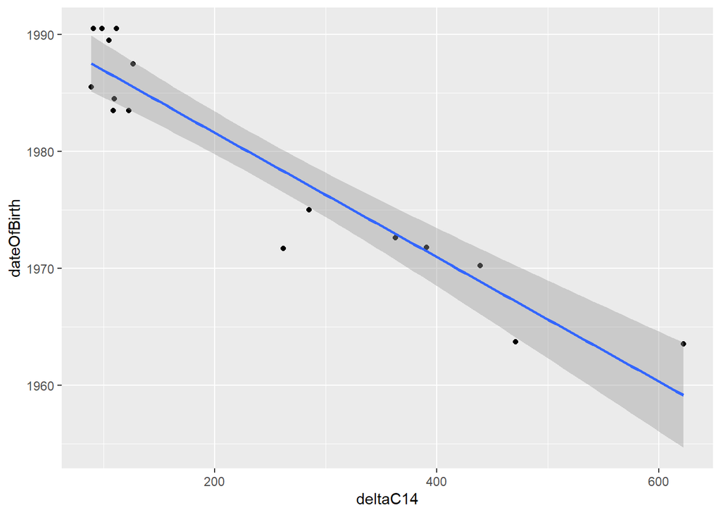

```r
zombies_lm <- lm(dateOfBirth ~ deltaC14, data = zombies)

ggplot(data = zombies, mapping = aes(x = deltaC14,
                                     y = dateOfBirth))+
  geom_point()+
  stat_smooth(method = lm)
```

```r
summary(zombies_lm)
```

```
##
## Call:
## lm(formula = dateOfBirth ~ deltaC14, data = zombies)
##
## Residuals:
##     Min      1Q  Median      3Q     Max
## -6.6135 -2.1205  0.0113  2.8884  4.3598
##
## Coefficients:
##               Estimate Std. Error t value Pr(>|t|)
## (Intercept)  1.992e+03  1.449e+00 1375.26  < 2e-16 ***
## deltaC14    -5.326e-02  5.004e-03  -10.64  4.3e-08 ***
## ---
## Signif. codes:  0 '***' 0.001 '**' 0.01 '*' 0.05 '.' 0.1 ' ' 1
##
## Residual standard error: 3.317 on 14 degrees of freedom
## Multiple R-squared:   0.89,  Adjusted R-squared:  0.8821
## F-statistic: 113.3 on 1 and 14 DF,  p-value: 4.296e-08
```

The slope of the line is -5.326e-02

The narrower dotted lines are the confidence bands. The confidence bands tell us the confidence interval for the predicted mean birth year for the given C14 decay.

The prediction interval measures the precision of single predicted values of birth year for decay of X rather than the mean.

Use broom and geom ribbon to make the plot above showing the data, dit and both intervals.

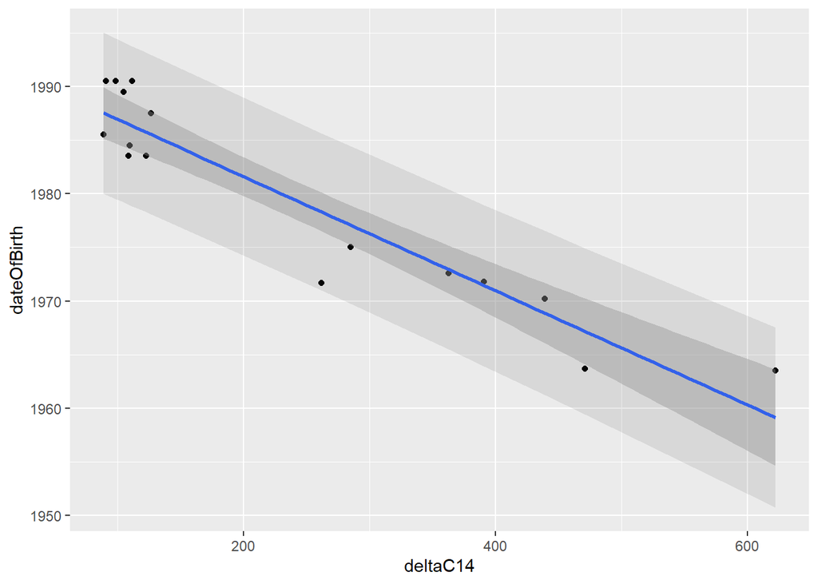

```r
zombie_pred <- augment(zombies_lm,
                       interval = "prediction")
ggplot(data = zombies, mapping = aes(x = deltaC14,
                                     y = dateOfBirth))+
  geom_point()+
  stat_smooth(method = lm)+
  geom_ribbon(data = zombie_pred, mapping = aes(y = .fitted,
                                                ymin = .lower,
                                                ymax = .upper),
              alpha = 0.1)
```

Meta 1: How well do you feel you understand the assumption testing behind a linear model? If there are elements that confuse you what are they? why?

I feel pretty good about the assumptions behind linear models. I think they make sense because we are trying to make sure the data is meeting these assumptions so that we can trust the model to represent predicitons of the data.

Meta 2: What concepts of linear regression are the clearest for you? Which are opaque?

I think meeting normality and the homogeneity of variance are the most clear and make the most sense to me while the linearity and the model fitting are most opaque however they make sense just not as much sense.

Meta 3: Even if you did not do the IYKYK part of this assignment, do you see how simulation can be used with a fit model? Do you feel it would be useful? Do you have gaps in your understanding about why simulation could work here?

I think I have a good grasp on bootstrapping and separately have a good grasp on linear models but do not understand when I would combine the two. I am unsure when it would be the case to use simulation.

Meta 4: This took me around 4-5 hours.

Meta 5: I grade myself as sufficient on this assignment because instead of building the answers from the lecture like before I had to dip into the reading for extra help. Not a bad thing but another step to understand which feels like more effort than previous lessons.